# Endotherm Model Tutorial I: theory, equations and subroutines

Warren P. Porter, Paul D. Mathewson & Michael R. Kearney

2026-04-01

# Theory

## I. Overview

This document summarises the main equations of the NicheMapR endotherm model ‘endoR’, within the subroutines and functions documented in the Endotherm Components Tutorial. It begins with an overview of the governing equations of the steady state heat budget, then expands the latter terms into the respective mechanistic terms. It then shows how these equations are rearranged to allow skin and fur-air interface boundary conditions to be calculated simultaneously as a function of the internal and external conditions. All symbols used, and their respective terms in the code, are summarised in section XVII at the end of this document.

## II. Governing heat balance equations

At steady state, the overall heat balance is:

$$\begin{align}
\tag{1}
Q_{gen,net} - Q_{evap} = Q_{fur} = Q_{env}
\end{align}$$

where

$$\begin{align}
\tag{2}
Q_{gen,net} = Q_{gen} - Q_{resp}
\end{align}$$

and

$$\begin{align}
\tag{3}
Q_{env} = Q_{rad} + Q_{conv} + Q_{cond} + Q_{evap,fur} - Q_{sol}.
\end{align}$$

These equations are stating that the net heat generated by the body, $Q_{gen,net}$, which is the total heat generated $Q_{gen}$ less that lost by respiration $Q_{resp}$, is equal to the heat passing through the fur $Q_{fur}$ after accounting for any heat lost by evaporation from the skin surface $Q_{evap}$. The heat exchanged with the environment through the fur is equal to the heat exchanged by long-wavelength radiation $Q_{rad}$, convection $Q_{conv}$, conduction $Q_{cond}$, evaporation from the fur surface $Q_{evap,fur}$ and solar radiation $Q_{sol}$.

By convention, $Q_{resp}$, $Q_{evap}$, $Q_{rad}$, $Q_{conv}$ and $Q_{cond}$ are considered to be losses, so negative values of these terms represent situations where heat is being gained through these processes. The reverse holds for $Q_{gen}$ and $Q_{sol}$.

Thus, at steady state:

$$\begin{align}
\tag{4}
Q_{fur} + Q_{sol} = Q_{rad} + Q_{conv} + Q_{cond} + Q_{evap,fur}
\end{align}$$

and

$$\begin{align}
\tag{5}
Q_{gen} + Q_{sol} = Q_{resp} + Q_{evap} + Q_{rad} + Q_{conv} + Q_{cond}
+ Q_{evap,fur}.
\end{align}$$

That is, at steady state for a particular core body temperature, the heat production by the body and the heat gain from any solar radiation must equal the overall heat lost by the combination of respiration, evaporation, long wavelength radiation, convection and conduction. Otherwise, the animal will not be in steady state and body temperature will rise or fall. Figure 1 provides a schematic of the overall heat transfer.

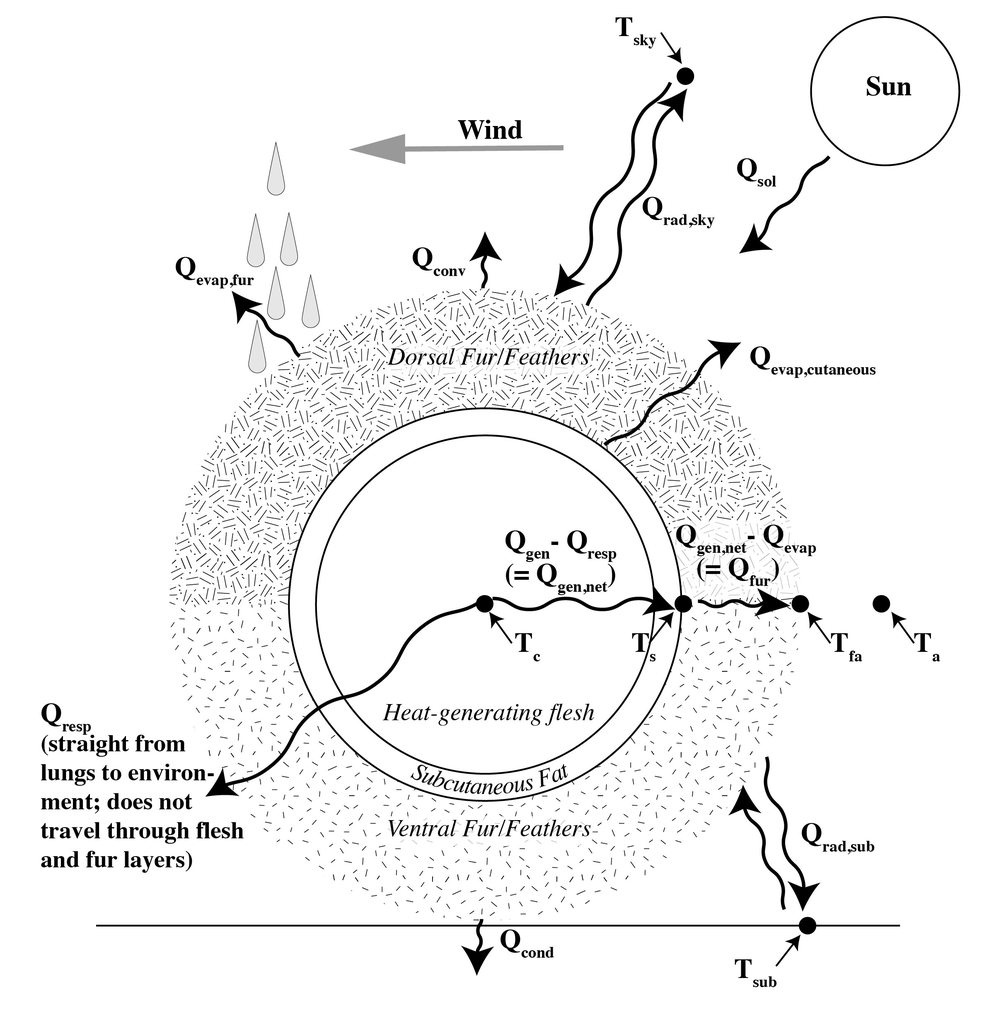

A cross section system diagram for heat flow in an animal

## III. Mechanism equations

We now expand the terms in the previous section to show their mechanistic underpinnings in relation to body dimensions, metabolic processes and the associated parameters and environmental forcing variables. These terms are further expanded in the ensuing sections that detail the subroutines and functions of the endoR program, including generalisation to different shapes; here we consider cylindrical geometry only (see also, Bird et al. 2002 for a general treatment of these kinds of problems).

The equation for net metabolic heat generation $Q_{gen,net}$ for a cylinder is:

$$\begin{align}
\tag{6}
Q_{gen,net} = \frac{T_c - T_s}{\frac{R^2_g}{4 k_g V_g} + \frac{R^2_g}{2
k_i V_g}\ln\left(\frac{R_s}{R_g}\right)}
\end{align}$$

where $T_c$ and $T_s$ are core and skin temperature, respectively, subscript $g$ means flesh (heat generating tissue), subscript $i$ means fat (insulating tissue), subscript $s$ means skin surface, $k$ is the thermal conductivity (units $\frac{\text{W}}{\text{m} \space ^\circ \text{C}}$), and $R$ is the radial dimension ($m$).

For a hollow cylinder of fur with no internal solar heat absorption, the heat flow is:

$$\begin{align}
\tag{7}
Q_{fur} = \frac{2 \pi k_{fur} L_g (T_s - T_{fa})}{\ln
\left(\frac{R_{fa}}{R_s}\right)}
\end{align}$$

where $k_{fur}$ is the fur thermal conductivity, $T_{fa}$ is the fur-air interface temperature and $R_{fa}$ is the radial distance from the centre of the animal to the fur-air interface. The length of the cylinder of flesh plus fat is represented by $L_g$.

Heat exchange via long wavelength radiation is quantified as:

$$\begin{align}
\tag{8}
Q_{rad} = \epsilon h_r A_{fa} (T_{rad,fur} - T_{rad,env})
\end{align}$$

where $\epsilon$ is the long wavelength emissivity, $h_r$ is a linear approximation of the difference of the 4th powers of the respective temperatures of the fur and environment, $h_r = 4 \sigma T^3_{ave}$, where $T_{ave} = \frac{T_{rad,fur} + T_{rad,env}}{2}$, $A_{fa}$ is the fur-air interface surface area, $T_{rad,fur}$ is the effective radiant temperature of the fur and $T_{rad,env}$ is the effective radiant temperature of the environment (e.g. sky, ground, bushes, and other nearby objects). Equation 8 closely approximates the exact Stefan-Boltzmann equation, $Q_{rad} = \epsilon \sigma A_{fa} (T^4_{rad,fur} - T^4_{rad,env})$, where $T$ is in Kelvin. There is only a 1.1% error when the temperature difference between $T_{rad,fur}$ and $T_{rad,env}$ is 60 $^\circ$C. This equation is expanded below in section XIV to account for configuration factors in different directions to different objects.

Heat loss by convection is quantified as:

$$\begin{align}
\tag{9}
Q_{conv} = h_c A_{fa} (T_{fa} - T_a)
\end{align}$$

where $T_a$ is air temperature and $h_c$ is the heat transfer coefficient (units $\frac{\text{W}}{\text{m}^{2\circ} \text{C}}$), which is usually determined experimentally and is a function of the geometric shape, wind speed and fluid properties (see section IX).

Heat lost by conduction is:

$$\begin{align}
\tag{10}
Q_{cond} = \frac{A_{cond} k_{sub}}{x_{sub}} (T_{fa} - T_{sub})
\end{align}$$

where $A_{cond}$ is the surface area of the animal in contact with the substrate, $T_{sub}$ is the substrate temperature, and $x_{sub}$ is the depth of the substrate from which the substrate temperature is taken.

The heat gained by solar radiation is:

$$\begin{align}
\tag{11}
Q_{sol} = A_{fa} \alpha I_{sol}
\end{align}$$

where $\alpha$ is the fur solar absorptivity and $I_{sol}$ is the incoming solar radiation ($\frac{\text{W}}{\text{m}^2}$). This is expanded in section VIII to be explicit about diffuse and direct components, from different directions.

The heat lost by evaporation is:

$$\begin{align}
\tag{12}
Q_{evap} = h_d A_{wet} (\rho_s- \rho_a) \lambda
\end{align}$$

where $A_{wet}$ is the surface area acting as a free-water surface, $h_d$ is the mass transfer coefficient, $\rho_s$ and $\rho_a$ are the water vapour densities at the skin surface and in the free stream air (outside the animal’s boundary layer), respectively, and $\lambda$ is the latent heat of vaporization.

Finally, the heat lost by respiration is:

$$\begin{align}
\tag{13}
Q_{resp} = (\dot{J}_{out} - \dot{J}_{in}) \lambda
\end{align}$$

where $\dot{J}_{in}$ and $\dot{J}_{out}$ are the mass flows of water in and out of the lungs, respectively.

## IV. Strategy to solve for the skin and fur-air interface temperatures

The heat balance equation (eq. 5) permits the calculation of the required metabolic rate for an animal to maintain a target body temperature under a given set of microclimate conditions. As illustrated in the solution below and in the terms of the previous section, the heat flux through each layer (core to skin; skin to fur-air interface; fur-air interface to environment) is dependent on the temperature gradient existing in each layer, the thermal conductivity of each layer, and the shape and dimensions of each layer. However, the only known temperatures for the model animals are the core temperature and the surrounding air temperature. We must calculate the skin temperature and the fur-air interface temperature in order to solve the heat balance and determine what metabolic rate is required for the animal to maintain its body temperature in its current environmental conditions.

In developing a solution for this heat budget, the following assumptions were made:

1. All solar is absorbed at the coat surface (i.e., does not penetrate into fur layer). This is a more appropriate assumption for birds than it is for mammals. The incorporation of variable penetration of solar radiation into fur is in development.
2. Evaporative heat loss $Q_{evap}$ takes place at the skin surface and thus this component of $Q_{gen,net}$ does not pass through the fur layer (i.e. equation 1), but additional evaporative heat loss may also occur from the fur surface via the term $Q_{evap,fur}$.
3. The remainder of net metabolic heat generation that is not lost through evaporation must be conducted and radiated through the fur/feather layer and then be convected, conducted and radiated away from the fur surface.
4. There is negligible free convection within the fur layer.
5. Respiratory heat loss does not affect skin or fur-air interface temperature.

From the above we can develop two equations for $T_s$ in the context of metabolic heat generation, one with and one without reference to $T_{fa}$:

From equation 6:

$$\begin{align}
\tag{14}
T_s = T_c - \frac{Q_{gen,net} R^2_g}{4 k_g V_g} - \frac{Q_{gen,net}
R^2_g}{2 k_i V_g} \ln\left(\frac{R_s}{R_g}\right).
\end{align}$$

From equation 7, but with $2 \pi L_g$ restated as $\frac{V_g}{R^2_g}$:

$$\begin{align}
\tag{15}
T_s = \frac{Q_{fur} R^2_g}{2 k_{fur} V_g}
\ln\left(\frac{R_{fa}}{R_s}\right) + T_{fa}
\end{align}$$

and from equation 1 (i.e. assumption 2 above):

$$\begin{align}
\tag{16}
T_s = \frac{(Q_{gen,net} - Q_{evap}) R^2_g}{2 k_{fur} V_g}
\ln\left(\frac{R_{fa}}{R_s}\right) + T_{fa}.
\end{align}$$

## Formulating equations in relation to the temperature of the fur-air interface

The challenge is to solve for $T_{fa}$ to calculate $Q_{rad}$, $Q_{conv}$, $Q_{evap,fur}$ and $Q_{cond}$, without using $T_s$ which, along with $Q_{gen}$, is an unknown value.

One important step for doing this is to write the heat balance in terms of $T_{fa}$ without $T_s$. This was derived in Mathewson and Porter (2013), but $Q_{cond}$ was not included. Here we derive the following equation for $T_{fa}$ that includes conduction.

First, the mechanism equation for $Q_{fur}$ needs to be modified to account for the fact that for an animal lying on the ground the portion of the surface in contact with the substrate will have its fur compressed, resulting a different fur thermal conductivity, $k_f$, and fur depth, which will in turn result in a different core-fur surface radius, $R_{fa}$.

Thus, incorporating conduction in the mechanism equation for $Q_{fur}$ described above in equation 7:

$$\begin{align}
\tag{17}
Q_{fur}= \left[\frac{2 \pi L_g
k_{f,cmp}}{\ln\left(\frac{R_{fa,cmp}}{R_s}\right)} \left(
T_s-T_{fa,cmp}\right) \right] PCOND + \left[\frac{2 \pi L_g k_f
}{\ln\left(\frac{R_{fa}}{R_s}\right)} \left( T_s-T_{fa}\right) \right]
\left(1 - PCOND \right)
\end{align}$$

where $T_{fa,cmp}$ is the fur surface temperature for the area in contact with the substrate, $PCOND$ is the proportion of the surface area that is in contact with the substrate, $k_{f,cmp}$ is the thermal conductivity of the compressed fur, and $R_{fa,cmp}$ is the core-to-fur surface radius for the portion of the animal in contact with the substrate.

With expansion and factoring this equation becomes:

$$\begin{align}
\tag{18}
Q_{fur} = 2 \pi L_g \\ \left[ T_s
\left(\frac{k_{f,cmp}}{\ln\left(\frac{R_{fa,cmp}}{R_s}\right)}
PCOND + \frac{k_f}{\ln\left(\frac{R_{fa}}{R_s}\right)} \left(1 -
PCOND\right) \right) - T_{fa,cmp}
\frac{k_{f,cmp}}{\ln\left(\frac{R_{fa,cmp}}{R_s}\right)} PCOND -
T_{fa} \frac{k_f}{\ln\left(\frac{R_{fa}}{R_s}\right)} \left(1 -
PCOND\right) \right]
\end{align}$$

where we can define new constants:

$$\begin{align}
\tag{19}
C_{d1} = \left(\frac{k_{f,cmp}}{\ln\left(\frac{R_{fa,cmp}}{R_s}\right)}
PCOND + \frac{k_f}{\ln\left(\frac{R_{fa}}{R_s} \right)} \left(1 -
PCOND \right) \right)
\end{align}$$

with units $\text{W} / \text{m} ^\circ \text{C}$,

$$\begin{align}
\tag{20}
C_{d2} = \frac{k_{f,cmp}}{\ln\left(\frac{R_{fa,cmp}}{R_s}\right)} PCOND
\end{align}$$

with units $\text{W} / \text{m} ^\circ \text{C}$, and

$$\begin{align}
\tag{21}
C_{d3} = \frac{k_f}{\ln\left(\frac{R_{fa}}{R_s}\right)} \left(1 - PCOND
\right)
\end{align}$$

with units $\text{W} / \text{m} ^\circ \text{C}$,

Modifying equation 16 to account for conduction:

$$\begin{align}
\tag{22}
T_s = \frac{(Q_{gen,net} - Q_{evap}) R^2_g}{2 V_g C_{d1}} +
\frac{T_{fa,cmp} C_{d2}}{C_{d1}} + \frac{T_{fa} C_{d3}}{C_{d1}}.
\end{align}$$

Overall, accounting for conduction, the heat balance in terms of $T_{fa}$ without $T_s$ is:

$$\begin{align}
\tag{23}
T_{fa} = \frac{\frac{2 \pi L_g}{D_1} (T_c C_{d1} - D_2 -
T_{fa,cmp}C_{d2})-h_r A_{fa} \frac{D_3}{D_4}-h_r A_{fa} \frac{T_{fa,cmp}
C_{d2}}{D_4}}{\frac{2 \pi L_g C_{d3}}{D_1}+h_r A_{fa}
\frac{\left(\frac{k_f}{ln\left(\frac{R_{fa}}{R_{rad}}\right)} \left(1 -
PCOND\right)\right)}{D_4}+h_c A_{fa}}\\ + \frac{h_r A_{fa} T_{env} + h_c
A_{fa} T_a - C_d T_{fa,cmp} +C_d T_{sub}-Q_{evap,fur} + Q_{sol}}{\frac{2
\pi L_g C_{d3}}{D_1}+h_r A_{fa}
\frac{\left(\frac{k_f}{ln\left(\frac{R_{fa}}{R_{rad}}\right)} \left(1 -
PCOND\right)\right)}{D_4}+h_c A_{fa}}
\end{align}$$

This is achieved by the following steps:

**Step 1** Setting up the balance in terms of the temperature of the fur-air interface

Equation 3, $Q_{fur} = Q_{rad} + Q_{conv} + Q_{cond} - Q_{sol}$, can be written using the mechanism equations defined above as:

$$\begin{align}
\tag{24}
2 \pi L_{g} \left(T_s C_{d1}-T_{fa,cmp} C_{d2}-T_{fa} C_{d3}\right) =
\epsilon h_r A_{fa} (T_{rad,fur} - T_{env}) + h_c A_{fa} (T_{fa} - T_a)
+ \\ C_d (T_{fa,cmp} - T_{sub}) + Q_{evap,fur} - Q_{sol}
\end{align}$$

where the constant $\frac{A_{cond} k_{sub}}{x_{sub}}$ in $Q_{cond}$ abbreviated as $C_d$, with units $\text{W} / ^\circ \text{C}$.

**Step 2** Eliminating skin temperature

First, to eliminate $T_s$ from $Q_{fur}$, we know from the body that $T_s = T_c - \frac{Q_{gen,net} R^2_g}{4 k_g V_g} - \frac{Q_{gen,net} R^2_g}{2 k_i V_g}\ln\left(\frac{R_{s}}{R_g}\right)$ (eq. 14), and we also know from the steady state that $Q_{gen,net} - Q_{evap} = Q_{fur}$ (eq. 1). Thus we can say:

$$\begin{align}
\tag{25}
T_s = T_c - \frac{(Q_{fur} + Q_{evap}) R^2_g}{4 k_g V_g} -
\frac{(Q_{fur} + Q_{evap}) R^2_g}{2 k_i
V_g}\ln\left(\frac{R_{s}}{R_g}\right).
\end{align}$$

Thus $Q_{fur}$ can be rewritten as:

$$\begin{align}
\tag{26}
Q_{fur} = 2 \pi L_{g} \left[\left(T_c - \frac{(Q_{fur} + Q_{evap})
R^2_g}{4 k_g V_g} - \frac{(Q_{fur} + Q_{evap}) R^2_g}{2 k_i
V_g}\ln\left(\frac{R_{s}}{R_g}\right)\right) C_{d1}-T_{fa,cmp}
C_{d2}-T_{fa} C_{d3}\right].
\end{align}$$

Then, by expanding and collecting $Q_{fur}$ terms and factoring out the $Q_{fur}$ terms, we obtain:

$$\begin{align}
\tag{27}
Q_{fur} \left[1 + \frac{2 \pi L_g R^2_g C_{d1}}{4 k_g V_g}+\left(\frac{2
\pi L_g R^2_g C_{d1}}{2 k_i
V_g}\ln\left(\frac{R_{s}}{R_g}\right)\right)\right] \\ = 2 \pi L_g
\left[T_c C_{d1} - \frac{Q_{evap} R^2_g C_{d1}}{4 k_g V_g} -
\frac{Q_{evap} R^2_g C_{d1}}{2 k_i V_g}\ln\left(\frac{R_{s}}{R_g}\right)
- T_{fa,cmp} C_{d2} - T_{fa} C_{d3}\right]
\end{align}$$

Defining the following constants:

$$\begin{align}
\tag{28}
D_1 = \left[1 + \frac{2 \pi L_g R^2_g C_{d1}}{4 k_g V_g}+\left(\frac{2
\pi L_g R^2_g C_{d1}}{2 k_i
V_g}\ln\left(\frac{R_{s}}{R_g}\right)\right)\right]
\end{align}$$

which is dimensionless, and

$$\begin{align}
\tag{29}
D_2 = \left[\frac{Q_{evap} R^2_g C_{d1}}{4 k_g V_g} + \frac{Q_{evap}
R^2_g C_{d1}}{2 k_i V_g}\ln\left(\frac{R_{s}}{R_g}\right)\right]
\end{align}$$

which has units of $\text{W} / \text{m}$, we thereby obtain

$$\begin{align}
\tag{30}
Q_{fur} = \frac{2 \pi L_g T_c C_{d1}}{D_1} - \frac{2 \pi L_g D_2}{D_1} -
\frac{2 \pi L_g T_{fa,cmp} C_{d2}}{D_1} - \frac{2 \pi L_g T_{fa}
C_{d3}}{D_1} = \frac{2 \pi L_g}{D_1} (T_c C_{d1} - D_2 -
T_{fa,cmp}C_{d2} - T_{fa} C_{d3}).
\end{align}$$

Now, inserting the new definition of $Q_{fur}$ into equation 24 we obtain:

$$\begin{align}
\tag{31}
\frac{2 \pi L_g}{D_1} (T_c C_{d1} - D_2 - T_{fa,cmp}C_{d2} - T_{fa}
C_{d3}) = h_r A_{fa} (T_{rad,fur} - T_{env}) + h_c A_{fa} (T_{fa} - T_a)
+ \\ C_d (T_{fa,cmp} - T_{sub}) + Q_{evap,fur} - Q_{sol}.
\end{align}$$

**Step 3**: Writing $T_{rad,fur}$ in terms of $T_{fa}$

We can define the radius at which longwave radiation is effectively leaving the fur, $R_{rad}$, as:

$$\begin{align}
\tag{32}
R_{rad} = R_s + \left[ X_r (R_{fa} - R_s) \right]
\end{align}$$

with $X_r$ being a fractional depth into the fur where radiant heat exchange takes place (1 - at the fur surface, 0.5 at the midpoint of the fur depth). For many animals, this may not be actual fur surface since IR can “see” into the fur for some given depth. Thus, the temperature gradient for $Q_{rad}$ may not be $T_{fa}-T_{rad,env}$. It could be something closer to $T_{s}-T_{rad,env}$. The $X_r$ term allows the user to choose where in the fur the radiant exchange takes place, and based on that choice, the $T_{rad,env}$ term is somewhere along the fur temperature profile between $T_{s}$ and $T_{fa}$.

Given the fur temperature profile, where the temperature of the fur $T_{fur}$ at a depth in the profile $r$ is

$$\begin{align}
\tag{33}
T_{fur} = \frac{\frac{(Q_{gen,net}-Q_{evap}) R^2_g}{2 V_g} + T_{fa,cmp}
C_{d2} + T_{fa} \left(\frac{k_f}{\ln\left(\frac{R_{fa}}{r}\right)}
\left(1-PCOND \right) \right)}{C_{d2} +
\frac{k_f}{\ln\left(\frac{R_{fa}}{r}\right)} \left(1-PCOND \right)}
\end{align}$$

then

$$\begin{align}
\tag{34}
T_{rad} = \frac{\frac{(Q_{gen,net}-Q_{evap}) R^2_g}{2 V_g} + T_{fa,cmp}
C_{d2} + T_{fa} \left(\frac{k_f}{\ln\left(\frac{R_{fa}}{R_{rad}}\right)}
\left(1-PCOND \right) \right)}{C_{d2} +
\frac{k_f}{\ln\left(\frac{R_{fa}}{R_{rad}}\right)} \left(1-PCOND
\right)}
\end{align}$$

where $Q_{gen,net} - Q_{evap} = Q_{fur} = \frac{2 \pi L_g}{D_1}(T_c C_{d1} - D_2 - T_{fa,cmp}C_{d2} - T_{fa} C_{d3})$, thus

$$\begin{align}
\tag{35}
T_{rad} = \frac{\left(\frac{2 \pi L_g}{D_1}\left(T_c C_{d1} - D_2 -
T_{fa,cmp} C_{d2} - T_{fa} C_{d3} \right)\right) R^2_g}{2 V_g
\left(C_{d2} + \frac{k_f}{\ln\left(\frac{R_{fa}}{R_{rad}}\right)}
\left(1-PCOND \right) \right)} \\ + \frac{T_{fa,cmp} C_{d2}}{C_{d2} +
\frac{k_f}{\ln\left(\frac{R_{fa}}{R_{rad}}\right)} \left(1-PCOND
\right)}+
\frac{T_{fa}\left(\frac{k_f}{\ln\left(\frac{R_{fa}}{R_{rad}}\right)}
\left(1-PCOND \right) \right)}{C_{d2} +
\frac{k_f}{\ln\left(\frac{R_{fa}}{R_{rad}}\right)} \left(1-PCOND
\right)}
\end{align}$$

where we can define new constants:

$$\begin{align}
\tag{36}
D_3 = \frac{\left(\frac{2 \pi L_g}{D_1}\left(T_c C_{d1} - D_2 -
T_{fa,cmp}C_{d2} - T_{fa} C_{d3} \right)\right) R^2_g}{2 V_g}
\end{align}$$

with units $\text{W} / \text{m}$,

$$\begin{align}
\tag{37}
D_4 = C_{d2} + \frac{k_f}{\ln\left(\frac{R_{fa}}{R_{rad}}\right)}
\left(1-PCOND \right)
\end{align}$$

with units $\text{W} / \text{m} ^\circ \text{C}$,

thus

$$\begin{align}
\tag{38}
Q_{rad} = h_r A_{fa} \left( \left( \frac{D_3}{D_4} + \frac{T_{fa,cmp}
C_{d2}}{D_4} + \frac{\frac{k_f}{\ln\left(\frac{R_{fa}}{R_{rad}}\right)}
\left(1-PCOND \right)}{D_4} \right) - T_{rad,env}\right)
\end{align}$$

and so $Q_{fur} = Q_{rad} + Q_{conv} + Q_{cond} + Q_{evap,fur} - Q_{sol}$ can be written with $T_s$ removed and $T_{rad,fur}$ in terms of $T_{fa}$:

$$\begin{align}
\tag{39}
\frac{2 \pi L_g}{D_1} (T_c C_{d1} - D_2 - T_{fa,cmp}C_{d2} - T_{fa}
C_{d3}) = \\ h_r A_{fa} \left( \left( \frac{D_3}{D_4} + \frac{T_{fa_cmp
C_{d2}}}{D_4} + \frac{\frac{k_f}{\ln\left(\frac{R_{fa}}{R_{rad}}\right)}
\left(1-PCOND \right)}{D_4} \right) - T_{rad,env}\right) + h_c A_{fa}
(T_{fa} - T_a) + \\ C_d (T_{fa,cmp} - T_{sub}) + Q_{evap,fur} - Q_{sol}.
\end{align}$$

Finally, expanding, rearranging and solving equation 39 for $T_{fa}$ we obtain equation 23.

This overall setup, i.e. equations 14, 22 and 23, are used in the subroutine SIMULSOL below to iteratively guess a $Q_{gen}$, $T_s$ and $T_{fa}$ that balances the heat budget for a given $T_c$.

Note: when $X_R = 1$, $\text T_{r} = T_{fa}$ and $\text R_{rad} = R_{fa}$. To avoid zeros in the denominator of some terms, eq. 31 is rewritten as:

$$\begin{align}
\tag{40}
\frac{2 \pi L_g}{D_1} (T_c C_{d1} - D_2 - T_{fa,cmp}C_{d2} - T_{fa}
C_{d3}) = h_r A_{fa} (T_{fa} - T_{env}) + h_c A_{fa} (T_{fa} - T_a) + \\
C_d (T_{fa,cmp} - T_{sub}) + Q_{evap,fur} - Q_{sol}.
\end{align}$$

And rearranging and solving for $\text T_{fa}$:

$$\begin{align}
\tag{41}
T_{fa} = \frac{\frac{2 \pi L_g}{D_1} (T_c C_{d1} - D_2-
T_{fa,cmp}C_{d2})+h_r A_{fa} T_{env} + h_c A_{fa} T_a - C_d T_{fa,cmp}
+C_d T_{sub} - Q_{evap,fur} + Q_{sol}}{\frac{2 \pi L_g C_{d3}}{D_1}+h_r
A_{fa}+h_c A_{fa}}
\end{align}$$

# Subroutines

We now describe the equations in further detail with respect to the separate Fortran subroutines of the endoR program, in the order in which they are called as shown in Fig. 2. These subroutines all have R wrappers so that they can be called separately. However, the overall process of solving the heat budget for a given environment, including behaviorual responses, is coordinated by the SOLVENDO subroutine, explained at the end of the document under section XV.

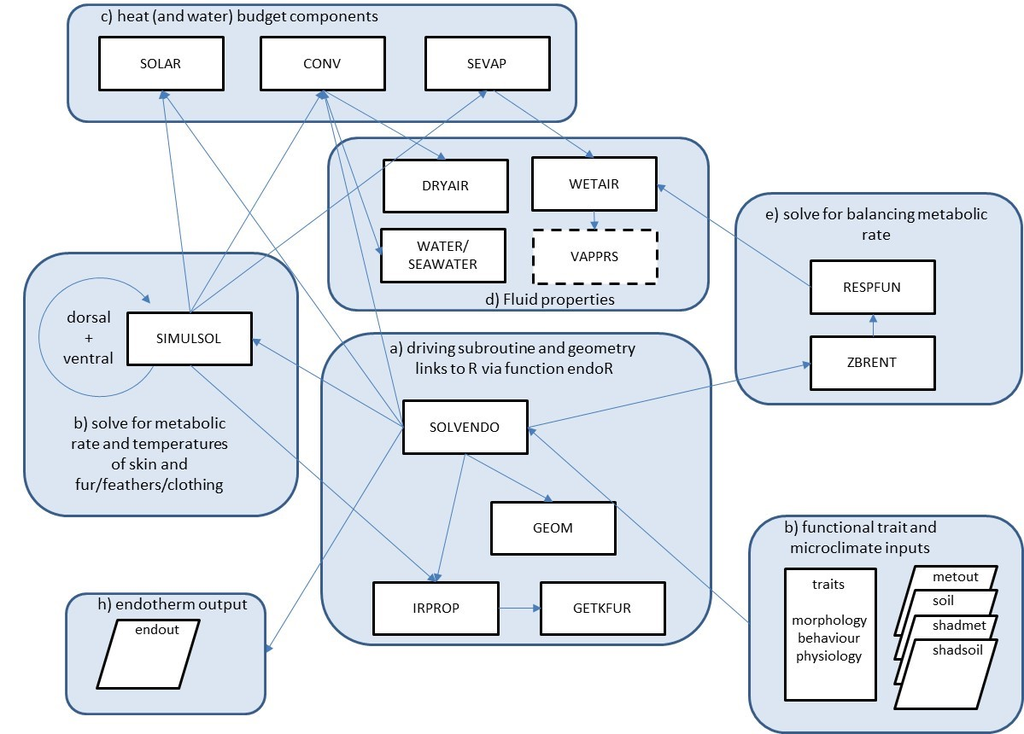

The relationship between subroutines of the endoR program in NicheMapR.

## V. IRPROP Subroutine

This subroutine tests for the presence of fur and coordinates the computation of the fur properties. It ultimately obtains the parameter $k_{eff}$, the effective conductivity of the fur, from which $k_{fur}$ is determined, and the average absorption coefficient $\beta$ and optical depth $\beta_1$, via the subroutine GETKFUR.

The IRPROP subroutine obtains these properties for the dorsal and ventral sides of the organism, as well as their weighted average based on the user input of the maximum percentage ventral fur. Note that the actual fraction of ventral fur may change as the organism changes from a curled to an uncurled posture, so the user may alter the percentage of ventral fur, $p_{vent}$, accordingly. In the SIMULSOL calculations, the entire body is first assumed to be ‘dorsal’ and then assumed to be ‘ventral’. This is accounted for in this subroutine by doubling the ventral percentage when weighting the ventral fur properties.

The $p_{vent}$ value is used in the weighted mean calculation of the fur density $\rho_{hair}$, hair diameter $D_{hair}$, hair length $L_{hair}$, fur depth $z_{fur}$ and absorptivity of the fur $\alpha_{fur}$.

The IRPROP function loops through the calculated average, dorsal and ventral fur properties and calls GETKFUR to obtain the conductive ($k_{eff}$) and longwave radiation ($\beta$ and $\beta_1$) fur properties for each and returns them. It also computes the conductivity of compressed fur for computing conduction to the substrate.

## VI. GETKFUR Subroutine

This subroutine takes as input the density and depth of the fur, its length, diameter and thermal conductivity, and computes $k_{eff}$, $\beta$ and $\beta_1$ as follows (from Conley and Porter 1986, modified from Kowalski 1976). Note that the optical depth, $\beta_1$, can be used to inform the value the user inserts for where in the fur is the effective fur temperature that is radiating to the environment.

The conductivity of the fur is computed along the horizontal direction $x(k^{\prime}_x)$ as a surface area weighted mean of air ($k_{air}$) and hair conductivity ($k_{hair}$):

$$\begin{align}
\tag{42}
k^{\prime}_x = A_{hair} k_{hair} + (1 - A_{hair}) k_{air}
\end{align}$$

where

$$\begin{align}
\tag{43}
A_{hair} = \rho_{hair} \pi \left(\frac{D_{hair}}{2}\right)^2
\end{align}$$

and $k_{air} = 0.02425+7.038\text{e-}5 \space T_a$, from the DRYAIR subroutine described in Properties of Air.

In the vertical direction $y(k^{\prime}_y)$, conductivity is expressed as

$$\begin{align}
\tag{44}
k^{\prime}_y = \rho_{hair,eff}^{\frac{1}{2}} k_{air}
(\rho^{-\frac{1}{2}}_{hair,eff}-D_{hair}) + \frac{D_{hair} k_{hair}
k_{air}}{D_{hair} k_{air} +
(\rho^{-\frac{1}{2}}_{hair,eff}-D_{hair})k_{hair}}
\end{align}$$

where the effective hair density is

$$\begin{align}
\tag{45}
\rho_{hair,eff} = \rho_{hair} (L_{hair} / z_{fur}).
\end{align}$$

Then, the effective conductivity of the fur is the average of these:

$$\begin{align}
\tag{46}
k_{eff} = \frac{k^{\prime}_x + k^{\prime}_y}{2}.
\end{align}$$

The average absorption coefficient, used in SIMULSOL to compute the conductivity to longwave radiation $k_{rad}$, is

$$\begin{align}
\tag{47}
\beta = \frac{0.67}{\pi} \rho_{hair,eff} D_{hair}
\end{align}$$

and the optical thickness is

$$\begin{align}
\tag{48}
\beta_1 = \beta z_{fur}.
\end{align}$$

The subroutine ensures that $k_{eff}$ does not go below $k_{air}$ as well as correcting for situations where hair diameter is impossibly large for the specified density, in which case $k_{eff}$ is capped at $k_{hair}$.

## VII. GEOM_ENDO Subroutine

This subroutine computes various lengths, areas, masses and volumes given the shape chosen, which presently includes a cylinder, sphere or ellipsoid. Specifically it computes:

- $V_{body}$, the total body volume, $\text{m}^3$
- $V_{fat}$, the volume of body fat, $\text{m}^3$
- $V_{g}$, the volume of body flesh, $\text{m}^3$
- $M_{fat}$, the mass of body fat, kg
- $z_{fat}$, fat layer thickness, m
- $D$, characteristic dimension for convection, m
- $L_{body}$, body length (flesh plus fat), m
- $W_{body}$, body width (flesh plus fat), m
- $H_{body}$, body height (flesh plus fat), m
- $R_s$, shape-specific core-skin radius in shortest dimension, m
- $R_{fa}$, shape-specific core-fur radius in shortest dimension, m
- $A_{maj}$, a semimajor axis length (ellipsoid), m
- $B_{min}$, b semiminor axis length (ellipsoid), m
- $C_{min}$, c semiminor axis length (ellipsoid, currently only prolate spheroid), m
- $H$, height, m
- $A_{tot}$, total area at fur/feathers-air interface, $\text{m}^2$
- $A_{sil}$, silhouette area for solar radiation, $\text{m}^2$ (may be normal, parallel or in between)
- $A_{sil,n}$, silhouette area normal to sun, $\text{m}^2$
- $A_{sil,p}$, silhouette area parallel to sun, $\text{m}^2$
- $A_{s}$, area of skin, $\text{m}^2$
- $A_{evap}$, area of skin for evaporation (total skin area - hair area), $\text{m}^2$
- $A_{conv}$, area for convection (total area minus ventral area, as determined by $p_{cond}$), $\text{m}^2$

These calculations are noted for each specific shape type in the sub-sections below. The relative dimensions for each shape are determined by the input parameters $S_b$ and $S_c$ which are ratios between axes of a given shape which, together with the specified mass $M$ and density $\rho_{body}$ and hence body volume ($V_{body} = \frac{M}{\rho_{body}}$), can be converted into absolute dimensions for each axis.

The mass of fat is $M_{fat} = p_{fat} M$ where the proportion fat $p_{fat}$ is a user-specified parameter. The volume of fat is thus $V_{fat} = M_{fat} / \rho_{fat}$ where fat density is assumed to be 901 $\text{kg}/\text{m}^3$ (Going, 1996).

For all shapes, the characteristic dimension for convection $D$ is assumed to be the cube root of the volume following Mitchell (1976):

$$\begin{align}
\tag{49}
D = V_{body}^{\frac{1}{3}}.
\end{align}$$

Also, for all shapes, once $A_{s}$ is computed, if fur is present the area for evaporative water loss is computed by subtracting the hair area using the weighted average hair properties between the dorsal and ventral sides:

$$\begin{align}
\tag{50}
A_{evap} = A_{s} - A_{s}\pi \left(\frac{D_{hair}}{2}\right)^2
\rho_{hair}.
\end{align}$$

Otherwise $A_{evap} = A_{s}$.

Similarly, the area for convection is corrected for the proportion of the area conducting to the substrate $p_{cond}$, i.e.

$$\begin{align}
\tag{51}
A_{conv} = A_{tot} - A_{tot} p_{cond}.
\end{align}$$

Otherwise $A_{conv} = A_{tot}$.

### Cylinder

For the cylinder, the radial dimension from core to skin is:

$$\begin{align}
\tag{52}
R_s = \frac{V_{body}}{2 \pi S_b}^{\frac{1}{3}}
\end{align}$$

and to the fur-air interface is thus $R_{fa} = R_s + z_{fur}$.

The length of the cylinder (flesh and insulating fat layer) is

$$\begin{align}
\tag{53}
L_{body} = 2 S_b R_s.
\end{align}$$

The skin area is

$$\begin{align}
\tag{54}
A_{s} = 2 \pi R_s^2 + 2 \pi R_s L_{body}
\end{align}$$

and the total area (at the fur-air interface) is

$$\begin{align}
\tag{55}
A_{tot} = 2 \pi R_{fa}^2 + 2 \pi R_{fa} L_{body}.
\end{align}$$

with the width $W_{body}$ and height $H_{body}$ being $2 R_{fa}$.

If a fat layer is present, the volume of flesh is simply $V_{g} = V_{body} - V_{fat}$ and the radius of the flesh is $R_{g} = \left(\frac{V_{g}}{\pi L_{body}}\right)^{-\frac{1}{2}}$, and the thickness of the fat layer is $R_{s} - R_{g}$. Otherwise, $V_{g} = V_{body}$ and $R_{g} = R_{s}$.

The silhouette area normal to the sun’s rays (maximising solar load) is $A_{sil,n} = W_{body} L_{body}$, and parallel (minimising solar load) is $A_{sil,p} = \pi R_{fa}^2$.

### Sphere

For the sphere, the radial dimension from core to skin is:

$$\begin{align}
\tag{56}
R_s = \frac{3V_{body}}{4\pi}^{\frac{1}{3}}
\end{align}$$

and to the fur-air interface is thus $R_{fa} = R_s + z_{fur}$.

The skin area is

$$\begin{align}
\tag{57}
A_{s} = 4 \pi R_s^2
\end{align}$$

and the total area (at the fur-air interface) is

$$\begin{align}
\tag{58}
A_{tot} = 4 \pi R_{fa}^2.
\end{align}$$

with the length $L_{body}$, width $W_{body}$ and height $H_{body}$ being $2 R_{fa}$.

If a fat layer is present, the volume of flesh is simply $V_{g} = V_{body} - V_{fat}$ and the radius of the flesh is $R_{g} = \left(\frac{3V_{g}}{4\pi}\right)^{\frac{1}{3}}$, and the thickness of the fat layer is $R_{s} - R_{g}$. Otherwise, $V_{g} = V_{body}$ and $R_{g} = R_{s}$.

The silhouette areas normal and parallel to the sun’s rays are of course identical $A_{sil,n} = A_{sil,p} = \pi R_{fa}^2$.

### Ellipsoid

For the ellipsoid, the semi-major and semi-minor axes are calculated as:

$$\begin{align}
\tag{63}
B_{min} = \left(\frac{3 V_{body}}{4 \pi S_b}\right)^{\frac{1}{3}}
\end{align}$$

$$\begin{align}
\tag{64}
A_{maj} = S_b B_{min}
\end{align}$$

with the assumption that $C_{min} = B_{min}$ (prolate ellipsoid).

Thus, $L_{body} = 2 A_{maj}$, and $W_{body} = H_{body} = 2 B_{min}$. The radius to skin is $R_{s} = B_{min}$ and the radius to the fur is $R_{fa} = R_{s} + z_{fur}$.

The skin area is

$$\begin{align}
\tag{65}
A_{s} = 2 \pi B^2_{min} + 2 \pi \frac{A_{maj} B_{min}}{E_s} \arcsin{E_s}
\end{align}$$

where the eccentricity for the skin $E_s$ is

$$\begin{align}
\tag{66}
E_s = \frac{(A_{maj}^2 - C_{min}^2)^{\frac{1}{2}}}{A_{maj}}.
\end{align}$$

The total area at the fur-air interface is

$$\begin{align}
\tag{67}
A_{tot} = 2 \pi (B^2_{min}+z_{fur}) + 2 \pi \frac{(A_{maj}+z_{fur})
(B_{min}+z_{fur})}{E_{tot}} \arcsin{E_{tot}}
\end{align}$$

where the eccentricity for the total area (at the fur-air interface) $E_{tot}$ is

$$\begin{align}
\tag{68}
E_{tot} = \frac{\left[(A_{maj}+z_{fur})^2 -
(C_{min}+z_{fur})^2\right]^{\frac{1}{2}}}{A_{maj}+z_{fur}}.
\end{align}$$

Alternatively, if the user parameter ‘SAMODE’ is set to 1, the skin and feather-air interface surface areas are computed according to empirical formulations for birds (Walsberg and King, 1978) that capture the fact that birds have a greater skin surface than feather-air interface surface:

$$\begin{align}
\tag{69}
A_{s} = 10M^{0.667}/10000
\end{align}$$

$$\begin{align}
\tag{70}
A_{tot} = 8.11M^{0.667}/10000.
\end{align}$$

Or, if ‘SAMODE’ is set to 2, the skin surface area is computed according to an empirical relationship for mammals (Stahl, 1976):

$$\begin{align}
\tag{71}
A_{s} = 1110M^{0.65}/10000
\end{align}$$

and this is then multiplied by the ratio of the results of equations 68 and 66 to obtain $A_{tot}$.

For the ellipsoid, the silhouette area normal to the sun’s rays (maximising solar load) is $A_{sil,n} = \pi (A_{maj}+z_{fur})(B_{min}+z_{fur})$, and parallel (minimising solar load) is $A_{sil,p} = \pi (B_{min}+z_{fur})(C_{min}+z_{fur})$.

If there is a fat layer, care must be taken in the calculation that fat layer thickness remains constant as shape changes. The volume of the flesh for the ellipsoid is:

$$\begin{align}
\tag{72}
V_{g} = \frac{4}{3} \pi (A_{maj} - z_{fat})(B_{min} - z_{fat})(C_{min} -
z_{fat})
\end{align}$$

where $z_{fat}$ is the fat thickness. This can be rearranged as:

$$\begin{align}
\tag{73}
z_{fat}^3 - (A_{maj} + B_{min} + C_{min}) z_{fat} ^ 2 + \left[(A_{maj}
B_{min})+(A_{maj}C_{min}) + (B_{min}C_{min}) \right] z_{fat} \\ +
\left[\frac{3V_{g}}{4 \pi} - (A_{maj} B_{min} C_{min})\right]=0
\end{align}$$

and is solved for $z_{fat}$ in the GEOM subroutine using the cubic formula.

Note that there comes a point at which the user-specified amount of fat is not enough to stretch over the surface area of the ellipsoid. The surface area will depend on the user-supplied a:b ratio, and if that is too large, creating a large surface area, fat thickness is calculated to be a negative number. In such circumstances, the subroutine sets fat thickness to zero for the simulations.

## VIII. SOLAR_ENDO Subroutine

This subroutine computes absorbed solar radiation $Q_{sol}$ for both the direct (point source) and diffuse (scattered) components reaching the dorsal and ventral halves of the organism. The direct solar beam radiation is

$$\begin{align}
\tag{74}
Q_{sol,dir}=\alpha_{dors} A_{sil} (1-p_{dif}) Q_{sol,norm} (1 - p_{shd})
\end{align}$$

where $\alpha_{dors}$ is the solar absorptivity of the dorsal area, $A_{sil}$ is the silhouette area (calculated above in GEOM), $Q_{sol,norm} = I_{sol}/\cos{Z}$ where $Z$ is the solar zenith angle in radians, $I_{sol}$ is the inputted horizontal plane solar radiation flux ($\text{W}/\text{m}^2$) and $p_{shd}$ is the fractional shade level.

The diffuse component from the sky is

$$\begin{align}
\tag{75}
Q_{sol,sky}=\alpha_{dors} F_{sky} A_{tot} p_{dif} Q_{sol} (1 - p_{shd})
\end{align}$$

where $F_{sky}$ is the configuration factor from animal to sky.

The diffuse component from the substrate is

$$\begin{align}
\tag{76}
Q_{sol,sub}=\alpha_{vent} F_{sub} A_{tot} p_{dif} (1-\alpha_{sub})
Q_{sol} (1 - p_{shd})
\end{align}$$

where $\alpha_{vent}$ is the solar absorptivity of the ventral area, $F_{sub}$ is the configuration factor from animal to substrate and $\alpha_{sub}$ is the solar absorptivity of the substrate.

Thus the total diffuse radiation absorbed $Q_{sol,dif} = Q_{sol,sky} + Q_{sol,sub}$, the dorsal solar absorbed is $Q_{sol,dors} = Q_{sol,dir} + Q_{sol,sky}$, and the ventral solar absorbed is $Q_{sol,vent} = Q_{sol,sub}$.

## IX. CONV_ENDO Subroutine

This subroutine computes the heat exchange by convection, $Q_{conv}$, as sum of the free (driven by the surface surface-free stream air temperature gradient) and forced (driven by wind speed) components. As indicated in equation 9, this requires calculation of the heat transfer coefficient

$$\begin{align}
\tag{77}
h_c=\frac{Nu \space k_{fluid}}{D}
\end{align}$$

where $D$ is the characteristic dimension (calculated in GEOM, eq. 49), $Nu$ is the Nusselt number and $k_{fluid}$ is the thermal conductivity of the fluid. The mass transfer coefficient $h_d$ can be computed from $h_c$ and used to quantify evaporative heat transfer, as described at the end of this section.

This subroutine allows the fluid to be air, fresh water or sea water. The thermal properties of dry air (which depend on temperature and pressure), including thermal conductivity, are computed by a call to the function DRYAIR which is part of the NicheMapR package and is fully described in Properties of Air. The thermal properties of fresh water and sea water (which depend on temperature) are obtained from the functions WATER and SEAWATER, respectively, described below.

The heat transfer coefficient is determined differently for the forced and free components.

### Free Convection

The Nusselt number for free convection is obtained from the Prandtl and Grashof numbers, all three numbers being dimensionless.

The Prandtl number is

$$\begin{align}
\tag{78}
Pr=\frac{C_{p,fluid} \mu}{k_{fluid}}
\end{align}$$

where $C_{p,fluid}$ is the specific heat capacity of the fluid which, for air, is 1005.7 $\text{J} / (\text{kg} \space ^\circ\text{C})$ but it is temperature-dependent for water as computed via WATER or SEAWATER, and $\mu$ is the dynamic viscosity as computed with DRYAIR, WATER or SEAWATER, accordingly.

The Grashof number is

$$\begin{align}
\tag{79}
Gr=\frac{\rho_{fluid}^2 \space \gamma \space G D^3 \delta_T}{\mu^2}
\end{align}$$

where $\rho_{fluid}$ is the fluid density (computed with DRYAIR, WATER or SEAWATER), $G$ is the acceleration due to gravity, $\gamma$ is the inverse of the free stream fluid temperature $T_a$ in Kelvin and $\delta_T$ is the temperature difference between the fluid and the relevant surface of the animal (skin or fur-air interface, depending on whether fur/feathers are present).

The equation for the Nusselt number varies with shape.

For a cylinder, following Kreith (1965), the relationship used is varied according to the Rayleigh number $Ra = Pr \space Gr$:

For $Ra < 0.1$,

$$\begin{align}
\tag{80}
Nu_{free}=0.976 Ra^{0.0784}.
\end{align}$$

For $0.1 < Ra < 100$,

$$\begin{align}
\tag{81}
Nu_{free}=1.1173 Ra^{0.1344}.
\end{align}$$

For $100 < Ra < 10000$,

$$\begin{align}
\tag{82}
Nu_{free}=0.7455 Ra^{0.2167}.
\end{align}$$

$Ra \ge 10000$,
$$\begin{align}
\tag{83}
Nu_{free}=0.5168 Ra^{0.2501}.
\end{align}$$

For a sphere or an ellipsoid, following Bird et al. (2002, equation 14.6-12, page 445):

$$\begin{align}
\tag{84}
Nu_{free}=2+0.60 Gr^{\frac{1}{4}} Pr^{\frac{1}{3}}.
\end{align}$$

### Forced Convection

The Nusselt number for forced convection is calculated with the dimensionless Reynold’s number

$$\begin{align}
\tag{86}
Re=\frac{\rho_{fluid} v D}{\mu}.
\end{align}$$

where $v$ is the wind speed ($\text{m} \text{s}^{-1}$).

For a cylinder (Kreith 1965):

For $Re < 4$,

$$\begin{align}
\tag{87}
Nu_{forced}=0.891 Re^{0.33}.
\end{align}$$

For $4 < Re < 40$,

$$\begin{align}
\tag{88}
Nu_{forced}=0.821 Re^{0.385}.
\end{align}$$

For $40 < Re < 4000$,

$$\begin{align}
\tag{89}
Nu_{forced}=0.615 Re^{0.466}.
\end{align}$$

For $4000 < Re < 40000$,

$$\begin{align}
\tag{90}
Nu_{forced}=0.174 Re^{0.618}.
\end{align}$$

$Re \ge 40000$,
$$\begin{align}
\tag{91}
Nu_{forced}=0.0239 Re^{0.805}.
\end{align}$$

For a sphere or an ellipsoid:

$$\begin{align}
\tag{92}
Nu_{forced}=0.37 Re^{0.6}.
\end{align}$$

### Combined free and forced convection

Once $Nu_{free}$ and $Nu_{forced}$ are determined, they can be combined as described in Bird et al. (2002):

$$\begin{align}
\tag{94}
Nu=(Nu_{free}^3 + Nu_{forced}^3)^{\frac{1}{3}}
\end{align}$$

and used to compute $h_c$ via equation 77 and $Q_{conv}$ via equation 9, i.e..

$$\begin{align}
\tag{95}
Q_{conv}=h_c A_{fa} (T_{fa} - T_{fluid})
\end{align}$$

where $T_{fa}$ is replaced by $T_s$ if no fur/feathers are present.

### Mass transfer coefficient

The mass transfer coefficient can be computed using the Chilton-Colburn analogy: $\frac{Sh}{Re \space Sc^{\frac{1}{3}}} = \frac{Nu}{Re \space Pr^{\frac{1}{3}}}$ where $Sh$ is the Sherwoood number and $Sc$ is the Schmidt number (the mass transfer analog of the Prandtl number).

$$\begin{align}
\tag{96}
Sc=\frac{\mu}{\rho_{fluid} d}
\end{align}$$

where $d$ is the mass diffusivity of water vapor ($\text{m}^2/\text{s}$).

Thus, from the Chilton-Colburn analogy:

$$\begin{align}
\tag{97}
Sh=Nu\left(\frac{Sc}{Pr}\right)^{\frac{1}{3}}
\end{align}$$

and the mass transfer coefficient is:

$$\begin{align}
\tag{98}
h_d=\frac{Sh \space d}{D}.
\end{align}$$

The overall $h_d$ is the sum of the values of $h_{d,free}$ (computed using $Nu_{free}$) and $h_{d,forced}$ (computed using $Nu_{forced}$).

## X. WATER Subroutine

This subroutine uses regressions fitted to relationships documented in List (1966).

For the specific heat capacity of freshwater:

$$\begin{align}
\tag{99}
C_{p,water}=4220.02-4.5531 \space T_{water}+0.182958 \space T_{water}^2
- 0.00310614 \space T_{water}^3 + \\ 1.89399\text{e-}5 \space
T_{water}^4.
\end{align}$$

For the thermal conductivity:

$$\begin{align}
\tag{100}
k_{fluid}=0.551666+0.00282144 \space T_{water}-2.02383\text{e-}5 \space
T_{water}^2.
\end{align}$$

For dynamic viscosity:

$$\begin{align}
\tag{101}
\mu_{fluid}=0.0017515-4.31502\text{e-}5 \space
T_{water}+3.71431E-7\text{e-}7 \space T_{water}^2.
\end{align}$$

For density ($\text{kg} / \text{m}^3$), water temperature is capped at 60 $^{\circ}\text{C}$, with

$$\begin{align}
\tag{102}
\rho_{fluid}=1017-0.6 T_{water}
\end{align}$$

for $T_{water}\ge30^{\circ}\text{C}$ and $\rho_{fluid}=1000$ for $T_{water}<30^{\circ}\text{C}$.

## XI. SEAWATER Subroutine

For the specific heat capacity of seawater:

$$\begin{align}
\tag{103}
C_{p,water}=3913.1369+1.0211143 \space T_{water}.
\end{align}$$

For the thermal conductivity:

$$\begin{align}
\tag{104}
k_{fluid}=6.751631+0.018687 \space T_{water}.
\end{align}$$

For dynamic viscosity:

$$\begin{align}
\tag{105}
\mu_{fluid}=6.751631-2.6\text{e-}5 \space T_{water}.
\end{align}$$

For density:

$$\begin{align}
\tag{106}
\rho_{fluid}=1029.82-0.27907 T_{water}.
\end{align}$$

## XIII. SEVAP_ENDO Subroutine

This subroutine computes aspects of evaporative heat loss including the term $Q_{evap}$ from equation 12 in Section III above. It takes as input the relative humidity $\text{RH}$, barometric pressure $P_{bar}$, air temperature $T_a$, the wind speed $v$, as well the mass transfer coefficient computed in CONV_ENDO $h_d$ (eq. 98, section IX above) and the skin surface area $A_s$ computed in GEOM. The WETAIR subroutine and its sub-function VAPPRS, described in Properties of Air is used to compute the skin (saturation) and air vapour densities, $\rho_s$ and $\rho_a$.

Evaporation may occur from the skin but also from the eyes, if they are assumed to be open, and from the fur or feathers, if wet from rain, licking or other sources. Evaporation from furred/feathered skin can occur via free convection-driven mass transport only, whereas both forced and free convection will drive evaporation from bare skin or from the fur/feather surface. Thus the effective area of the skin for evaporation, $p_{wet} A$, will vary for these different scenarios.

Thus, cutaneous water loss is partitioned as

$$\begin{align}
\tag{107}
\dot{M}_{\text{H}_2\text{O},furskin} = h_{d,free} p_{wet} (1 - p_{bare})
A_s (\rho_s - \rho_a).
\end{align}$$

and

$$\begin{align}
\tag{108}
\dot{M}_{\text{H}_2\text{O},bareskin} = h_{d} p_{wet} p_{bare} A_s
(\rho_s - \rho_a)
\end{align}$$

where $p_{bare}$ is a user input determining the proportion of the free-water surface (not total skin surface) that is bare skin. Thus $\dot{M}_{\text{H}_2\text{O},cut} = \dot{M}_{\text{H}_2\text{O},furskin} + \dot{M}_{\text{H}_2\text{O},bareskin}$.

If the organism is in a state of flight (bird/bat), it is assumed that forced and free mass transport drive evaporation (i.e., effectively $p_{bare} = 1$).

If the eyes are open, an additional amount contributes to non-respiratory evaporation:

$$\begin{align}
\tag{109}
\dot{M}_{\text{H}_2\text{O},eyes}=h_d p_{eyes} A_s (\rho_s - \rho_a).
\end{align}$$

Finally, the fraction of the fur/feather surface area that is wet is determined by the user input $p_{wetfur}$ and

$$\begin{align}
\tag{110}
\dot{M}_{\text{H}_2\text{O},wetfur} = h_{d} p_{wetfur} A_{tot} (\rho_s -
\rho_a).
\end{align}$$

The subroutine reports the separate mass losses of water as well as the heat lost by evaporation from the skin/eyes and the fur.

## XIV. SIMULSOL Subroutine

This subroutine simultaneously solves for the skin and fur-air interface temperature that balances the heat budget for a non-respiring part of the body, as described above, accounting for dorsal and ventral differences and evaporation from the skin. It is the core of the endotherm model.

There are two sections to this subroutine, one for the case that fur/feathers are present, and one for when the skin is bare. The most complex solution is for when fur is present, as there are three unknowns to solve for, as explained in section IV above. The approach taken in SIMULSOL is as follows (we do not describe the bare skin approach in detail here as it is a simpler version of the approach below):

### Step 1.

Guess an initial fur-air interface temperature $T_{fa}$ to get things started since the $h_c$ and $h_r$ terms in the final $T_{fa}$ calculation depend on $T_{fa}$. The first guess is air temperature, $T_a$. Also the term $Q_{evap,fur}$ needs a $T_{fa}$ to be calculated.

### Step 2.

Guess an initial skin temperature $T_s$ because $Q_{evap}$ depends on $T_s$. The first $T_s$ guess is core temperature $T_c$.

### Step 3.

With the initial $T_s$ guess, calculate $T_{fa,cmp}$. For the part of the ventral surface area in contact with the substrate, we can assume that the only heat flux with the environment is through conduction, and thus

$$\begin{align}
\tag{111}
Q_{fur,cnd} = Q_{cond}.
\end{align}$$

Inserting mechanism equations as an example for cylinders:
$$\begin{align}
\tag{112}
\frac{2 \pi L_g k_{f,cmp} PCOND}{\ln\left(\frac{R_{fa,cmp}}{R_s}\right)}
\left( T_s-T_{fa,cmp}\right) = \frac{A_{cnd} k_{sub}}{x_{sub}} \left(
T_{fa,cmp}-T_{sub}\right)
\end{align}$$

where we can define constants:

$$\begin{align}
\tag{113}
C_f = \frac{2 \pi L_g k_{f,cmp}
PCOND}{\ln\left(\frac{R_{fa,cmp}}{R_s}\right)}
\end{align}$$

with units $\text{W} / ^\circ \text{C}$,

$$\begin{align}
\tag{114}
C_d = \frac{A_{cnd} k_{sub}}{x_{sub}}
\end{align}$$

with units $\text{W} / ^\circ \text{C}$

Solving for $T_{fa,cmp}$:
$$\begin{align}
\tag{115}
T_{fa,cmp} = \frac{C_f T_s + C_d T_{sub}}{C_d + C_f}
\end{align}$$

### Step 4.

Calculate $T_{fa}$ from the equation 23 in Section IV. Note that the effective fur thermal conductivity $k_{eff}$ depends on air temperature in the fur, which is assumed to be a weighted mean of $T_s$ and $T_{fa}$ (relative weightings 0.7 and 0.3, respectively), thus with each new estimate of $T_s$ and $T_{fa}$ the IRPROP routine is called to get a temperature-adjusted $k_{eff}$ estimate.

The $T_{fa}$ guess is also used to calculate the $h_c$ and $h_r$ terms and the $T_s$ guess to calculate $Q_{evap}$. This calculation is made by calls to CONV_ENDO and SEVAP_ENDO to get the heat and mass transfer coefficients and estimates of $Q_{evap}$ from the skin and fur.

### Step 5.

As part of the initial calculation of $T_{fa}$, the longwave radiation exchange components must be determined. An estimate of the longwave radiation component of fur thermal conductivity $k_{rad}$ is obtained following Conley and Porter (1986, eq. 7):

$$\begin{align}
\tag{116}
k_{rad}=\frac{16 \sigma (T_{rad,approx} + 273.15)^3}{3 \beta}
\end{align}$$

where $\sigma$ is the Stefan-Boltzmann constant, $\beta$ is the average absorption coefficent from equation 47 computed in GETKFUR, and an initial approximation of fur radiant temperature $T_{rad,fur}$ is

$$\begin{align}
\tag{117}
T_{rad,approx}=T_s (1-X_r) + T_{fa} X_r
\end{align}$$

which takes into account the depth where the user assumes longwave radiation exchange is occurring (see step 3, section IV, above).

This allows the value of $k_{fur}$ to be finalised, since $k_{eff}$ was already calculated via IRPROP and GETKFUR, and

$$\begin{align}
\tag{118}
k_{fur}=k_{eff} + k_{rad}.
\end{align}$$

Also, in section IV above, $Q_{rad}$ was not broken into its various components. This is done in SIMULSOL as follows.

The complete $Q_{rad}$ is

$$\begin{align}
\tag{119}
Q_{rad}=Q_{rad,sky}+Q_{rad,sub}+Q_{rad,bsh}+Q_{rad,veg}.
\end{align}$$

Inserting the mechanism equations

$$\begin{align}
\tag{120}
Q_{rad}=h_{r,sky} A_{fa} (T_{rad,fur} - T_{rad,sky})+h_{r,sub} A_{fa}
(T_{rad,fur} - T_{rad,sub})+ \\ h_{r,bsh} A_{fa} (T_{rad,fur} -
T_{rad,bsh})+h_{r,veg} A_{fa} (T_{rad,fur} - T_{rad,veg})
\end{align}$$

where $sub$ is substrate, $bsh$ is a bush or other nearby object on the ground whose geometry is defined, and $veg$ is vegetation overhead. Combining the relevant area $A$ and the radiant heat transfer coefficient $h_r$ for each of the four terms we obtain

$$\begin{align}
\tag{121}
Q_{rad}= Q_{r1} (T_{rad,fur} - T_{rad,sky})+ Q_{r2} (T_{rad,fur} -
T_{rad,sub})+Q_{r3} (T_{rad,fur} - T_{rad,bsh}) \\ + Q_{r4} (T_{rad,fur}
- T_{rad,veg}).
\end{align}$$

As eq. 23 is being developed to find $T_{fa}$ in SIMULSOL, the $Qr$ terms are calculated as:

$$\begin{align}
\tag{122}
Q_{r1}= A_{fa} F_{sky} 4 \epsilon \sigma (T_{rad,fur})^3
\end{align}$$

$$\begin{align}
\tag{123}
Q_{r2}= A_{fa} F_{sub} 4 \epsilon \sigma (T_{rad,fur})^3
\end{align}$$

$$\begin{align}
\tag{124}
Q_{r3}= A_{fa} F_{bsh} 4 \epsilon \sigma (T_{rad,fur})^3
\end{align}$$

$$\begin{align}
\tag{125}
Q_{r4}= A_{fa} F_{veg} 4 \epsilon \sigma (T_{rad,fur})^3
\end{align}$$

where $F$ terms are the respective, user-specified configuration factors.

### Step 6.

Adjust the $T_{fa}$ guess until it matches up with the calculated $T_{fa}$. This is done by first adjusting the $T_{fa}$ starting guess to match the $T_{fa}$ calculated in Step 4 and calculating another $T_{fa}$ using equation 23. If that procedure fails to produce convergence within acceptable error bounds, a new iterative guessing procedure is initiated. In the procedure $T_{fa}$ is set to a guess that is the average of the previous and current $T_{fa}$ values calculated in Step 4. A final approach is to adjust the $T_{fa}$ guess incrementally in the direction of the $T_{fa}$ calculated in Step 4 to avoid large jumps, particularly when dealing with evaporation at high temperature.

### Step 7.

Note in general that the approach is not truly an analytical solution because one needs a guess to get a balance. This guessing is needed because $h_c$ and $h_r$ depend on $T_{fa}$ and $T_{fa}$ cannot be extracted from those equations.

### Step 8.

At this point, the $T_{fa}$ guess used to calculate $h_c$ and the $h_r$ values in the $T_{fa}$ equation and the $T_s$ guess used to calculate $Q_{evap}$ both match the calculated $T_{fa}$ and $T_s$ values at steady state. We can thus calculate the $Q_{gen,net}$, $Q_{fur}$, and $Q_{env}$ for an animal in steady state.

### Step 9.

Check that 1) the two $T_s$ calculations give the same skin temperature, within specified tolerance and 2) that $Q_{gen,net}-Q_{evap}=Q_{fur}=Q_{env}$.

NOTE: in the special case where PCOND = 1, there is a different solution procedure since there is no $T_{fa}$ to solve for, only $T_{fa,cmp}$.

In this case, since there is no evaporation, convection, radiation or solar input, the heat balance is:

$$\begin{align}
\tag{126}
Q_{gen,net}= Q_{fur} = Q_{cnd}
\end{align}$$

Focusing on the $Q_{fur} = Q_{cnd}$ portion of the heat balance with the mechanism equations inserted:

$$\begin{align}
\tag{127}
Q_{fur}= \frac{2 \pi L_g
k_{f,cmp}}{\ln\left(\frac{R_{fa,cmp}}{R_s}\right)} \left(
T_s-T_{fa,cmp}\right) = C_{d} \left( T_{fa,cmp}-T_{sub}\right)
\end{align}$$

where the constant $\frac{2 \pi L_g k_{f,cmp}}{\ln\left(\frac{R_{fa,cmp}}{R_s}\right)}$ is abbreviated $C_{f1}$ with units $\text{W} / ^\circ \text{C}$.

The $T_s$ definition from eq. 14 is unchanged in this special case. However, the other $T_s$ definition from eq. 16 is modified:
$$\begin{align}
\tag{128}
T_s = \frac{(Q_{gen,net} - Q_{evap}) R^2_g}{2 k_{fur,cmp} V_g}
\ln\left(\frac{R_{fa,cmp}}{R_s}\right) + T_{fa,cmp}.
\end{align}$$

Eliminating $T_s$ from eq. 127 by using these mechanism equations for $T_s$ and solving for $T_{fa,cmp}$ similarly to how $T_{fa}$ was solved for above:

$$\begin{align}
\tag{129}
T_{fa,cmp} = \frac{\frac{C_{f1}}{D_5} + C_d
T_{sub}}{C_d+\frac{C_{f1}}{D_5}}.
\end{align}$$

where $\text D_{5}$ is the unitless term $\left[1 + \frac{C_{f1} R^2_g}{4 k_g V_g} + \frac{C_{f1} R^2_g}{2 k_I V_g}\ln\left(\frac{R_{s}}{R_g}\right)\right]$.

### Step 1a.

Calculate $T_{fa,cmp}$ from eq. 129.

### Step 2a.

Using the $T_{fa,cmp}$ calculation, calculate $Q_{cond}$ using eq. 10. Recognising that $Q_{cond} = Q_{gen,net}$ we can also calculate $T_s$ using eqs. 14 and 128.

### Step 3a.

Check that 1) the two $T_s$ calculations give the same skin temperature, within specified tolerance and 2) that $Q_{gen,net} = Q_{fur} = Q_{cond}$.

Note that all of the calculations done here are for the cylindrical geometry and will be different for other geometries.

## XIV. RESPFUN

This subroutine is a molar balance for computing water loss from breathing, as represented in Figure 3. It uses the oxygen demand for maintaining a core temperature to compute the amount of air flowing in and out of the lungs and hence the heat lost by evaporation. The user can specify the ambient gas levels so that, for instance, conditions in a burrow can be simulated.

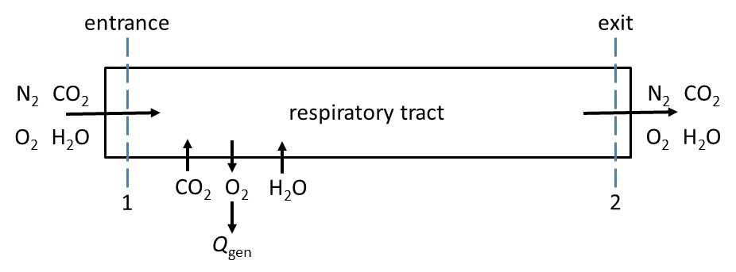

The exchange of respiratory gases entering the respiratory tract at imagainary surface 1, with carbon dioxide and water vapour added from the body and oxygen consumed according to the metabolic rate and the remainder exiting the body at imaginary surface 2. Figure modified from Porter et al. (2000)

The required $\text{O}_2$ consumption rate at standard temperature and pressure, $\dot{V}_{O_{2},stp}$, is determined from the value of $Q_{gen}$ passed to the function via the SOLVENDO and ZBRENT subroutines (see below). If that value is lower than the specified minimum metabolic rate, $Q_{basal}$, then $Q_{basal}$ is used instead.

The conversion to litres of $\text{O}_2$ per second depends on the respiratory quotient, $\text{RQ}$ (ratio of moles of $\text{CO}_2$ produced per mole of $\text{O}_2$ consumed), as follows:

$$\begin{align}
\tag{130}
\dot{V}_{O_{2},stp}= \frac{Q_{gen} X_{act}}{4.185 \cdot 1000} X_{RQ}
\end{align}$$

where $X_{act}$ is a user-specified activity multiplier, the denominator is a conversion factor from kilocalories to joules, and $X_{RQ}$ is a conversion factor for litres of $\text{O}_2$ per kilocalorie taken from Kleiber (1961) where, if $\text{RQ} = 1$, $X_{RQ} = 1/5.057$ (carbohydrate diet), if $\text{RQ} \le 0.7$, $X_{RQ} = 1/4.7$ (fat diet), or else if $X_{RQ} = 1/4.5$ (protein diet).

This value is then converted to actual volume consumed per second given the current air temperature and barometric pressure ($P_{bar}$):

$$\begin{align}
\tag{131}
\dot{V}_{O_2}= \frac{\dot{V}_{O_{2},stp} P_{bar,std}}{273.15}
\frac{T_{a}+273.15}{P_{bar}}.
\end{align}$$

The moles of $\text{O}_2$ consumed is then

$$\begin{align}
\tag{132}
\dot{J}_{\text{O}_2,con} = \frac{\dot{V}_{O_2} P_{bar}}{R(T_{a} +
273.15)}
\end{align}$$

Where $R$ is the universal gas constant (= 8309.28 $\frac{\text{Pa} \space \text{Litres}}{\text{mol} \space \text{K}}$).

Then the moles of $\text{O}_2$ entering the respiratory system is at imaginary surface 1 in Fig. 3 is

$$\begin{align}
\tag{133}
\dot{J}_{\text{O}_2,1} =
\frac{\dot{J}_{\text{O}_2,con}}{\kappa_{\text{O}_2}}
\end{align}$$

where $\kappa_{\text{O}_2}$ is the fractional oxygen extraction efficiency of the lungs.

To convert this $\text{O}_2$ requirement into the molar flow of air through the lungs,

$$\begin{align}
\tag{134}
\dot{J}_{\text{air},1} = \dot{J}_{\text{O}_2,1} \frac{p_{\text{N}_2} +
p_{\text{O}_2} + p_{\text{CO}_2}}{p_{\text{O}_2}}
\frac{p_{\text{O}_2,ref}}{p_{\text{O}_2}}
\frac{P_{\text{O}_2,ref}}{P_{\text{O}_2}} X_{pant}
\end{align}$$

where $p_{\text{O}_2}$, $p_{\text{CO}_2}$ and $p_{\text{N}_2}$ are the proportions of each gas in the animal’s environment and $p_{\text{O}_2,ref}$, $p_{\text{CO}_2,ref}$ and $p_{\text{N}_2,ref}$ are the respective reference atmospheric proportions, $P_{\text{O}_2} = p_{\text{O}_2} P_{bar}$ is the partial pressure of $\text{O}_2$ and $P_{\text{O}_2,ref} = p_{\text{O}_2} P_{bar,ref}$ is the reference partial pressure of $\text{O}_2$. The atmospheric proportions of $\text{O}_2$ and $\text{N}_2$ are fixed at 0.2095 and 0.7902, respectively, while that of $\text{CO}_2$ is a user input to account for anthropogenic emissions changes. $X_{pant}$ is a multiplier to allow for enhanced respiratory heat loss via panting as part of the thermoregulatory response.

The volume of air flowing through the lungs per second is then

$$\begin{align}
\tag{135}
\dot{V}_{air} = \dot{J}_{\text{air},1} R \frac{273.15}{101325}.
\end{align}$$

The moles of water entering the respiratory system can then be computed as

$$\begin{align}
\tag{136}
\dot{J}_{\text{H}_2\text{O},1} = \dot{V}_{air}
\frac{P_{\text{H}_2\text{O},sat} \frac{\text{RH}}{100}}{P_{bar} -
P_{\text{H}_2\text{O},sat} \frac{\text{RH}}{100}}
\end{align}$$

where $P_{\text{H}_2\text{O},sat}$, the saturation water vapour pressure, is computed via the WETAIR subroutine and its sub-function VAPPRS, as described in Properties of Air.

The moles of $\text{O}_2$ exiting the respiratory system (imaginary surface 2, Fig. 3) is

$$\begin{align}
\tag{137}
\dot{J}_{\text{O}_2,2} = \dot{J}_{\text{O}_2,1} -
\dot{J}_{\text{O}_2,con}.
\end{align}$$

The moles of air at exit (imaginary surface 2) will be approximately the same at entrance, since the moles of $\text{O}_2$ removed is nearly the same as the moles of $\text{CO}_2$ added. The molar air flow rate at exit is

$$\begin{align}
\tag{138}
\dot{J}_{\text{air},2} = (\dot{J}_{\text{O}_2,2} +
\dot{J}_{\text{CO}_2,2}) \frac{p_{\text{N}_2} +
p_{\text{O}_2}}{p_{\text{O}_2}} \frac{p_{\text{O}_2,ref}}
{p_{\text{O}_2}} \frac{P_{\text{O}_2,ref}}{P_{\text{O}_2}} X_{pant}
\end{align}$$

where $\dot{J}_{\text{CO}_2,2} = \text{RQ} \cdot \dot{J}_{\text{O}_2,2}$.

The moles per second of water leaving the organism is

$$\begin{align}
\tag{139}
\dot{J}_{\text{H}_2\text{O},2} = \dot{J}_{\text{air},2}
\frac{P_{\text{H}_2\text{O},sat}}{P_{bar} - P_{\text{H}_2\text{O},sat}}.
\end{align}$$

The mass of water lost in kilograms per second is then

$$\begin{align}
\tag{140}
\dot{M}_{\text{H}_2\text{O},2} = 18 \cdot
(\dot{J}_{\text{H}_2\text{O},2} - \dot{J}_{\text{H}_2\text{O},1}) \cdot
1000
\end{align}$$

where the value 18 is the molar mass of water.

Finally, the respiratory heat lost is

$$\begin{align}
\tag{141}
Q_{resp} = \lambda \dot{M}_{\text{H}_2\text{O},2} - Q_{air}
\end{align}$$

where $\lambda$ is the latent heat of vaporisation, computed as $2.5012\text{e+}06 - 2.3787\text{e+}03 \cdot T_{lung}$, with $T_{lung}$ assumed to be the average of the current skin and core temperature, and $Q_{air} = C_{p,air} \dot{J}_{\text{air},1} \cdot 0.0289647 \cdot (T_{a}-T_{lung})$ is the heat taken by the air where 0.0289647 is the the molar mass of air (kg/mol).

## XV. SOLVENDO and ZBRENT

Within the ‘while loop’, after the initial calls to IRPROP, GEOM_ENDO, SOLAR_ENDO, CONV_ENDO, another loop calls SIMULSOL twice, once for the dorsal and once for the ventral side. For each call, the whole animal is simulated to have the fur/feather properties of the side being considered, and to be exposed in all directions to the environment of that side (i.e. sky or ground). Then, a final averaged value is obtained for $Q_{gen,net}$, $T_s$ and $T_{fa}$, weighted by the configuration factors to the the sky plus vegetation ($F_{sky} + F_{veg}$), versus the remainder ($1 - (F_{sky} + F_{veg})$).

The weighted mean guess of $Q_{gen,net}$ from the SIMULSOL calls is finally passed to RESPFUN via the root finding function ZBRENT (Brent, 2002) to calculate $Q_{resp}$ by guessing for a value of $Q_{gen}$ that balances the relationship in equation 2, i.e. that $Q_{gen,net} = Q_{gen} - Q_{resp}$. This guessing process is needed because $Q_{resp}$ is dependent on total $Q_{gen}$, not simply $Q_{gen,net}$. Once a suitable value for $Q_{resp}$ is found, it can be added to the value of $Q_{gen,net}$ to determine $Q_{gen}$ and the value of $Q_{gen,net}$ can be checked against the user-provided minimum value to see whether the while-loop can be terminated.

## XVI References

Brent, R. (2002) Algorithms for minimization without derivatives, Dover Publications.

Conley, K.E. & Porter, W.P. (1986) Heat loss from deer mice (Peromyscus): evaluation of seasonal limits to thermoregulation. Journal of Experimental Biology, 126, 249–269.

Going, S.B. (1996) Densiometry. Human Body Composition (ed. by A.F. Roche), S.B. Heymsfield), and T.G. Lohman), pp. 3–24. Human Kinetics Press, Champaign, IL.

Kleiber, M. (1961) The Fire of Life. An Introduction to Animal Energetics.

Kreith, F. (1965) Principles of Heat Transfer, International Textbook Co, Scranton, Pa.

Kowalski, G.J. (1978) An Analytical and Experimental Investigation of the Heat Loss Through Animal Fur.

List, R.J. (1966) Smithisonian Meteorological Tables, 6th Ed. Smithonian Institute, Washington, D.C.

Mathewson, P.D. & Porter, W.P. (2013) Simulating Polar Bear Energetics during a Seasonal Fast Using a Mechanistic Model. PLoS One, 8, e72863.

Mitchell, J.W. (1976) Heat transfer from spheres and other animal forms. Biophysical Journal, 16, 561–569.

Porter, W.P., Budaraju, S., Stewart, W.E., Ramankutty, N. (2000) Calculating climate effects on birds and mammals: impacts on biodiversity, conservation, population parameters, and global community structure. American Zoologist, 40, 597-630.

Stahl, W.R. (1967) Scaling of respiratory variables in mammals. Journal of Applied Physiology, 22, 453–460.

Walsberg, G.E. & King, J.E. (1978) The Relationship of the External Surface Area of Birds to Skin Surface Area and Body Mass. Journal of Experimental Biology, 76, 185–189.

## XVII Symbols

| Symbol | units | Variable Name | Description |
| --- | --- | --- | --- |
| $\alpha_{dors}$ | $\text{none, ratio}$ | $\text{ABSAND}$ | solar absorptivity, dorsal fur |
| $\alpha_{fur}$ | $\text{none, ratio}$ | - | solar absorptivity, fur |
| $\alpha_{sub}$ | $\text{none, ratio}$ | $\text{ABSSB}$ | solar absorptivity, substrate |
| $\alpha_{vent}$ | $\text{none, ratio}$ | $\text{ABSANV}$ | solar absorptivity, ventral fur |
| $\beta$ | $\text{m}^{-1}$ | $\text{BETARA}$ | average infrared absorption coefficient |
| $\beta_1$ | $\text{m}$ | $\text{B1ARA}$ | fur/feather optical depth |
| $\delta_T$ | $\text{K},^\circ \text{C}$ | $\text{DELTAT}$ | temperature difference between animal surface and surrounding air/fluid |
| $\epsilon$ | $\text{none, ratio}$ | $\text{EMIS}$ | longwave emissivity |
| $\gamma$ | $\text{K}^{-1}$ | $\text{BETA}$ | inverse of the fluid temperature $T_{fluid}$ in Kelvin |
| $\lambda$ | $\text{J} \space \text{kg}^{-1}$ | $\text{HTOVPR}$ | latent heat of vaporization |
| $\mu$ | $\text{kg} \space \text{m} \space \text{s}^{-1}$ | $\text{VISDYN}$ | dynamic viscosity of air or fluid surrounding the animal |
| $\mu_{fluid}$ | $\text{kg} \space \text{m} \space \text{s}^{-1}$ | $\text{VISDYN}$ | dynamic viscosity of fluid surrounding the animal |
| $\rho_{body}$ | $\text{kg} \space \text{m}^{-3}$ | $\text{ANDENS}$ | body density |
| $\rho_{fat}$ | $\text{kg} \space \text{m}^{-3}$ | $\text{FATDEN}$ | fat density |
| $\rho_{fluid}$ | $\text{kg} \space \text{m}^{-3}$ | $\text{DENSTY}$ | fluid density |
| $\rho_{fur}$ | $\text{hairs} \space \text{m}^{-2}$ | $\text{RHO}$ | weighted mean calculation of pelage hair density |
| $\rho_{hair,eff}$ | $\text{hairs} \space \text{m}^{-2}$ | $\text{RHOEFF}$ | effective pelage hair density |
| $\rho_{hair}$ | $\text{hairs} \space \text{m}^{-2}$ | $\text{RHO}$ | pelage hair density |
| $\rho_a$ | $\text{kg} \space \text{m}^{-3}$ | $\text{AIRVD}$ | vapor density of surrounding air |
| $\rho_s$ | $\text{kg} \space \text{m}^{-3}$ | $\text{SURFVD}$ | vapor density at the skin surface |
| $\sigma$ | $\text{W} \space \text{m}^{-2} \text{K}^{-4}$ | $\text{SIG}$ | Stefan-Boltzmann constant |
| $A_{cond}$ | $\text{m}^2$ | $\text{AV}$,$\text{AREACND}$ | area of body part in contact with substrate for conduction |
| $A_{conv}$ | $\text{m}^2$ | $\text{SURFAR}$,$\text{CONVAR}$ | area for convection (total area minus ventral area in contact with substrate, as determined by $p_{cond}$) |
| $A_{evap}$ | $\text{m}^2$ | $\text{CONVSK}$,$\text{AREASKIN}$ | area of skin for evaporation (total skin area - hair area) |
| $A_{fa}$ | $\text{m}^2$ | $\text{CONVAR}$ | fur-air interface area |
| $A_{hair}$ | $\text{m}^2$ | $\text{AHAIR}$ | cross-sectional fur area that is hair (rather than air) |
| $A_{maj}$ | $\text{m}$ | $\text{ASEMAJ}$ | semimajor axis length (ellipsoid) |
| $A_{s}$ | $\text{m}^2$ | $\text{CONVSK}$,$\text{AREASKIN}$ | area of skin, $\text{m}^2$ |
| $A_{sil,n}$ | $\text{m}^2$ | $\text{ASILN}$ | silhouette area normal to sun |
| $A_{sil,p}$ | $\text{m}^2$ | $\text{ASILP}$ | silhouette area parallel to sun |

[output cut: 178 more lines]